# Projet Apprentissage Léa KAISER

Léa KAISER

17/12/2021

```r
library(tidyverse)
library(ggpubr)
library(rstatix)
library(caret)
library(e1071)
library(glmnet)
```

# 1. Chargement et préparation de données réelles

Pour réaliser ce projet, on considère le jeu de données de cancer du sein METABRIC que l’on a trouvé sur Kaggle.

### 1.1 Charger le jeu de données, le décrire et préparer le jeu de données pour le projet:

```r
cancer <- read.csv("~/M2 stats/apprentissage statistique/projet/METABRIC_RNA_Mutation.csv")
view(cancer)
```

1. **créer une variable à expliquer Y binaire, qui vaut 1 pour les patientes décédées en raison du cancer et 0 pour les autres.**

La variable que nous allons prendre comme variable à expliquer est la variable “death from cancer”, qui est divisée en trois groupes: * Living * Died of Disease * Died of other Causes

On mettra 1 pour les patientes décédées en raison du cancer et 0 pour les autres, c’est-à-dire celles qui ne sont pas décédées du cancer et celles qui sont décédées pour d’autres raisons.

```r
if(any(cancer$death_from_cancer=="Died of Disease"))cancer$death_from_cancer<-ifelse(cancer$death_from_cancer=="Died of Disease",1,0)

head(cancer$death_from_cancer)
```

```
## [1] 0 0 1 0 1 1
```

J’ai ensuite renommer la variable death_from_cancer en l’appelant Y (qui sera notre variable à expliquer)

```r
which(colnames(cancer)=="death_from_cancer") #trouver le numero de la colonne
colnames(cancer)[31] <-"Y"
cancer[31]
```

2. **ne garder que les variables âge au diagnostic, taille de la tumeur et nombre de mutations parmi les variables cliniques (c’est-à-dire autres qu’expressions de gènes et mutations). Les valeurs manquantes de taille de la tumeur ou nombre de mutations pourront au choix être supprimées ou imputées en utilisant la médiane de la chacune des variables.**

On va ensuite recréer un dataframe **cancerdata** avec la variable à expliquer Y que l’on vient de faire dans le **a)** et avec les autres variables demandées.

```r
cancerdata<-data.frame(cancer$Y,cancer$age_at_diagnosis,cancer$tumor_size,cancer$mutation_count,cancer[32:693])
view(cancerdata)
```

J’ai ensuite renommé les variables cliniquesparce que suite à la création de mon nouveau dataframe on avait par exemple cancer.Y au lieu de tout simplement Y

```r
colnames(cancerdata)[1]<-"Y"
colnames(cancerdata)[2]<-"age_diagnosis"
colnames(cancerdata)[3]<-"tumor_size"
colnames(cancerdata)[4]<-"mutation_count"
```

Une fois ce dataframe créé, il fallait soit supprimer soit imputer par la médiane de la variable, les valeurs manquantes pour la variable **tumor size** et **mutation count**. J’ai donc d’abord regardé combien de valeurs manquantes comportait ce jeu de données (il y en avait très peu, 20 pour la taille de la tumeur et 45 pour le nombre de mutations).

Et j’ai donc décidé d’imputer les valeurs manquantes par la médiane de chaque variable.

```r
#imputation des valeurs manquantes

cancerdata<-cancerdata%>%
  mutate(tumor_size=replace_na(tumor_size,median(tumor_size,na.rm=TRUE)))

cancerdata<-cancerdata%>%
  mutate(mutation_count=replace_na(mutation_count,median(mutation_count,na.rm=TRUE)))
```

3. **modifier les données de mutations en variables binaires comportant un 1 pour chaque mutation, quelque soit le code la décrivant.**

Pour cette partie, j’ai procédé de la même manière que pour la création de la variable à expliquer Y. J’ai dit que si les mutations étaient égales à 0, on ne changeait pas la valeur on reste à 0 sinon pour toutes les autres valeurs on les remplaçait par 1 (là où il y a des mutations quelque que soit le code la décrivant).

```r
if(any(cancerdata[494:666]==0))cancerdata[494:666]<-ifelse(cancerdata[494:666]==0,0,1)
```

Nous avons désormais préparé le jeu de données que nous allons utiliser pour les parties 2 et 3.

# 2. Prédiction

### 2.2 Choisir trois méthodes de prédiction vues en cours (en expliquant pourquoi vous prenez ces méthodes) ainsi que les méthodes de réduction de dimension suivantes:

J’ai décidé de choisir les trois méthodes de prédiction suivantes:

-> **Méthode de prédiction avec forêt aléatoire.**  
Les forêts aléatoires sont tout d’abord un gain par rapport à un seul arbre. Elles permettent une sélection de variable évitant un risque de sur-apprentissage et donc une meilleure prédiction.

-> **Méthode de prédiction SVM**  
Cette méthode nécessite peu de paramètres à régler et est simple à la mise en oeuvre.

-> **Méthode de prédiction avec la pénalité**  
LA régression pénalisée permet de gérer la corrélation entre variables ou encore la sélection des variables. Deux types de pénalités: Lasso pour la sélection de variable et Ridge pour la corrélation entre variables. On peut cependant utiliser Elastic-net qui est un bon compromis entre les deux autres types de pénalités.

1. **aucune**  
   Dans un premier temps on ne fera pas de réduction de dimension:
2. **forêt aléatoire**

```r
#On sépare dans un premier temps le jeu un jeu d'apprentissage et un jeu test

#pour la suite, il faut que Y soit un facteur pour que caret comprenne qu'on fait de la classification, et il faut choisir des noms valides donc pas des chiffres

cancerdata <- cancerdata %>% mutate(Y=as.factor(ifelse(Y==0,"no","yes")))

inTrain <- createDataPartition(
  y = cancerdata$Y,
  p = .75,
  list = FALSE
)

cancertraining <- cancerdata %>% slice(n=inTrain)
cancertest <- cancerdata %>% slice(n=-inTrain)
```

on va ensuite régler le paramètre de contrôle avec une validation croisée

```r
ctrl <- trainControl(
  #method = "oob",
  method="repeatedcv",
  number=10,
  repeats = 3,
  classProbs = TRUE,
  summaryFunction = twoClassSummary
)
```

Puis on va maintenant dans le jeu d’apprentissage

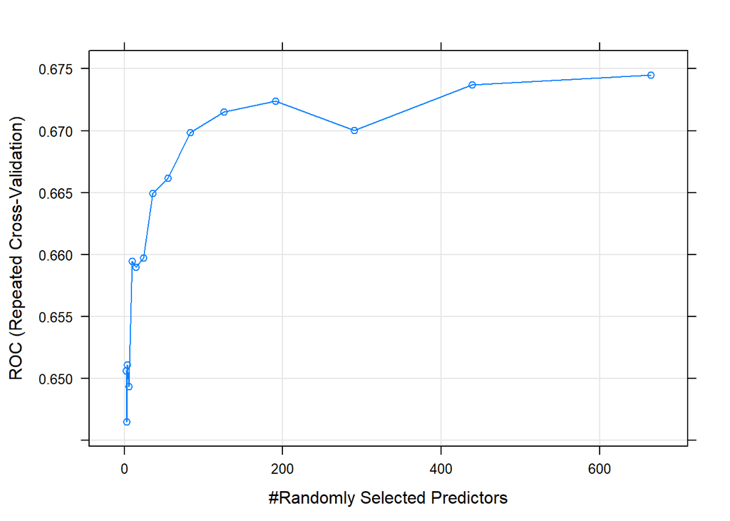

```r
rfFit <- train(
  Y ~ .,
  data = cancertraining,
  method = "rf",
  tuneLength = 15, #donne le nombre de valeurs à essayer pour chaque paramètre à faire varier (ici nombre de variables à prendre en compte)
  trControl = ctrl,
  metric = "ROC"
)

#pour comparer les méthodes, on peut choisir la métrique ROC (=classer les individus dans le bon ordre), qui est une des sorties de twoClassSummary.

plot(rfFit)
```

Le modèle ayant la meilleure prédiction par validation croisée est alors sous **finalModel** dans la sortie.

```r
decision <- rfFit$finalModel
```

Pour finir, regardons les performances de l’arbre ainsi appris sur le jeu test

```r
cartPred <- predict(rfFit,cancertest)

confusionMatrix(data=cartPred,cancertest$Y)
```

```
## Confusion Matrix and Statistics
##
##           Reference
## Prediction  no yes
##        no  295 129
##        yes  25  26
##
##                Accuracy : 0.6758
##                  95% CI : (0.6316, 0.7177)
##     No Information Rate : 0.6737
##     P-Value [Acc > NIR] : 0.4827
##
##                   Kappa : 0.1084
##
##  Mcnemar's Test P-Value : <2e-16
##
##             Sensitivity : 0.9219
##             Specificity : 0.1677
##          Pos Pred Value : 0.6958
##          Neg Pred Value : 0.5098
##              Prevalence : 0.6737
##          Detection Rate : 0.6211
##    Detection Prevalence : 0.8926
##       Balanced Accuracy : 0.5448
##
##        'Positive' Class : no
##
```

Pour effectuer cette méthode, on a deux types de SVM. Le SVM linéaire ou alors le SVM à noyaux. J’ai décidé d’effectuer les deux pour voir lequel propose le meilleur modèle de prédiction.

Le début est exactement le même que pour les forêt aléatoires. On a toujours le jeu d’apprentissage et le jeu test. On réutilise donc les mêmes. Donc dans un premier temps, on est sur le jeu d’apprentissage.

```r
linearsvm <-  svm(formula = Y~.,
                  data = cancertraining,
                  type = 'C-classification',
                  kernel = 'linear')
gaussiansvm <- svm(formula = Y~.,
                   data = cancertraining,
                   type = 'C-classification',
                   kernel = 'radial')
```

Une fois les deux méthodes apprises, on va faire la prédiction sur le jeu test.

```r
linearpred <- predict(linearsvm, newdata = cancertest)
gaussianpred <- predict(gaussiansvm, newdata = cancertest)
```

et on sort les matrices de confusion pour les deux méthodes

```r
confusionMatrix(data=linearpred,cancertest$Y)
```

```
## Confusion Matrix and Statistics
##
##           Reference
## Prediction  no yes
##        no  210  95
##        yes 110  60
##
##                Accuracy : 0.5684
##                  95% CI : (0.5225, 0.6135)
##     No Information Rate : 0.6737
##     P-Value [Acc > NIR] : 1.0000
##
##                   Kappa : 0.0423
##
##  Mcnemar's Test P-Value : 0.3282
##
##             Sensitivity : 0.6562
##             Specificity : 0.3871
##          Pos Pred Value : 0.6885
##          Neg Pred Value : 0.3529
##              Prevalence : 0.6737
##          Detection Rate : 0.4421
##    Detection Prevalence : 0.6421
##       Balanced Accuracy : 0.5217
##
##        'Positive' Class : no
##
```

```r
confusionMatrix(data=gaussianpred,cancertest$Y)
```

```
## Confusion Matrix and Statistics
##
##           Reference
## Prediction  no yes
##        no  294 135
##        yes  26  20
##
##                Accuracy : 0.6611
##                  95% CI : (0.6165, 0.7036)
##     No Information Rate : 0.6737
##     P-Value [Acc > NIR] : 0.7387
##
##                   Kappa : 0.0584
##
##  Mcnemar's Test P-Value : <2e-16
##
##             Sensitivity : 0.9187
##             Specificity : 0.1290
##          Pos Pred Value : 0.6853
##          Neg Pred Value : 0.4348
##              Prevalence : 0.6737
##          Detection Rate : 0.6189
##    Detection Prevalence : 0.9032
##       Balanced Accuracy : 0.5239
##
##        'Positive' Class : no
##
```

iii. **méthode de régression pénalisée**

Pour la regréssion pénalisée, on a trois types: Lasso, Ridge et Elastic-Net.

Le début est exactement le même que pour les forêt aléatoires. On a toujours le jeu d’apprentissage et le jeu test. On réutilise donc les mêmes. Donc dans un premier temps, on est sur le jeu d’apprentissage.

```r
#jeu d'apprentissage
y.train <- cancertraining %>% select(Y) %>% as.matrix()
x.train <- cancertraining %>% select(-Y) %>% as.matrix()
```

Pénalité Ridge

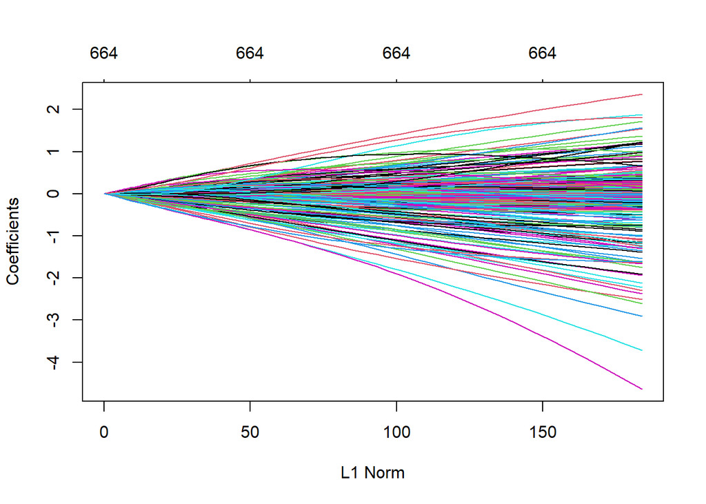

```r
model.ridge <- glmnet(x.train,y.train,family = "binomial",alpha=0)
plot(model.ridge)
```

Pénalité Lasso

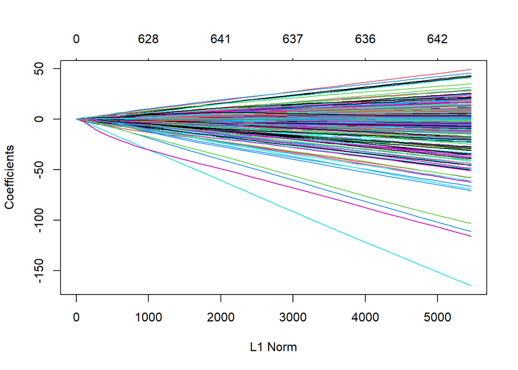

```r
model.lasso <- glmnet(x.train,y.train,family = "binomial",alpha=1)
plot(model.lasso)
```

Pénalité Elastic net

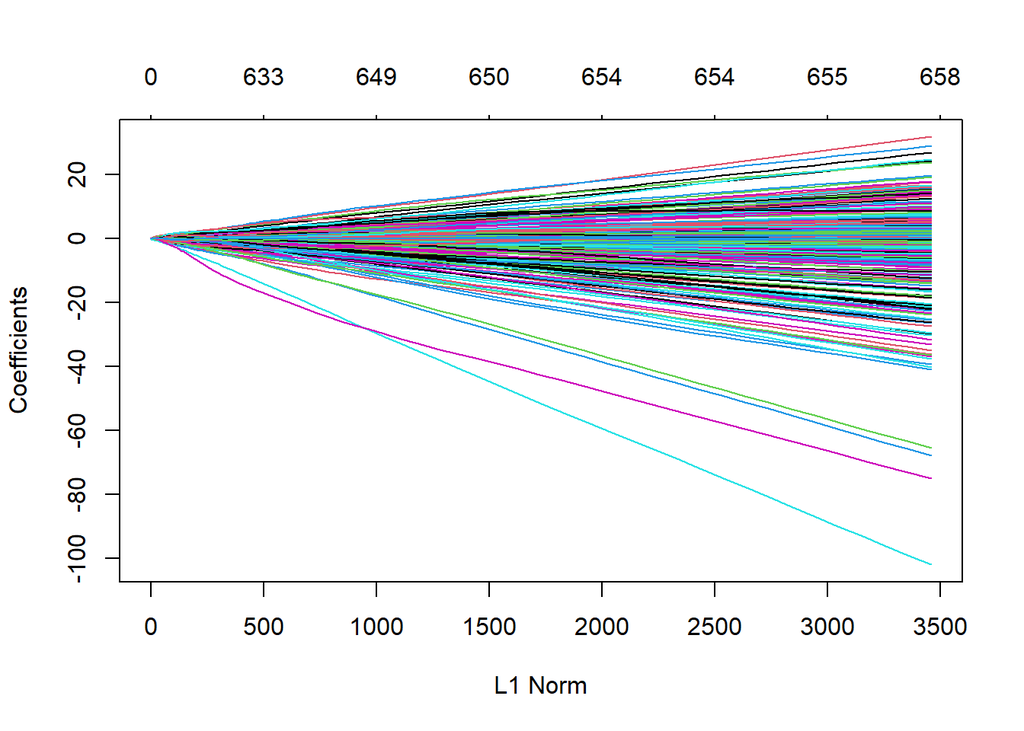

```r
model.enet <- glmnet(x.train,y.train,family = "binomial",alpha=0.5)
plot(model.enet)
```

Une fois la pénalité choisi (ici je décide de choisir elastic net, car c’est un bon compromis entre Ridge et Lasso), on procède par validation croisé pour la prédiction.

```r
cancer.cv <- cv.glmnet(x.train,y.train,nfolds=5,family="binomial")
cancer.cv$lambda.min
```

```
## [1] 0.02368238
```

```r
model.en.cv <- glmnet(x.train,y.train,family="binomial",alpha=0.5,nlambda=1,lambda=cancer.cv$lambda.min)
```

```r
cancerpredict.en.cv <- predict(model.en.cv,x.train,type="response",family="binomial")
results <- tibble(proba=cancerpredict.en.cv,MAP=round(cancerpredict.en.cv),truth=(y.train=="yes")*1)
results
```

```
## # A tibble: 1,429 x 3
##    proba[,"s0"] MAP[,"s0"] truth[,"Y"]
##           <dbl>      <dbl>       <dbl>
##  1       0.0845          0           0
##  2       0.0998          0           0
##  3       0.415           0           0
##  4       0.365           0           1
##  5       0.560           1           1
##  6       0.185           0           0
##  7       0.223           0           0
##  8       0.312           0           0
##  9       0.308           0           1
## 10       0.0999          0           0
## # ... with 1,419 more rows
```

```r
confusionMatrix(data=as_factor(results$MAP),as_factor(results$truth))
```

```
## Confusion Matrix and Statistics
##
##           Reference
## Prediction   0   1
##          0 911 307
##          1  51 160
##
##                Accuracy : 0.7495
##                  95% CI : (0.7262, 0.7718)
##     No Information Rate : 0.6732
##     P-Value [Acc > NIR] : 1.933e-10
##
##                   Kappa : 0.3371
##
##  Mcnemar's Test P-Value : < 2.2e-16
##
##             Sensitivity : 0.9470
##             Specificity : 0.3426
##          Pos Pred Value : 0.7479
##          Neg Pred Value : 0.7583
##              Prevalence : 0.6732
##          Detection Rate : 0.6375
##    Detection Prevalence : 0.8523
##       Balanced Accuracy : 0.6448
##
##        'Positive' Class : 0
##
```

2. **par ACP (ou PLS si vous connaissez cette méthode)**

On va dans un premier réalisé une ACP afin de réduire la dimension.

```r
acp=prcomp(cancerdata[,2:666])

#prcomp qui effectue une analyse en composante principale sur la matrice de données
```

Une fois l’ACP réalisé, on cherche ensuite à prendre les variables nécessaire pour expliquer entre 70 et 80% des résultats (ici j’ai décidé de prendre 80%)

```r
m<-which((cumsum(acp$sdev)/sum(acp$sdev))>(80/100))[1]
#sdev<-les écarts types des composantes principales
#où cumsum<-Renvoie un vecteur dont les éléments sont les sommes cumulées,
val=as_tibble(acp$x[,1:m])
```

et enfin une fois les variables sélectionnées en créer à nouveau le jeu d’apprentissage et le jeu test pour pouvoir à nouveau appliquer les trois méthodes vu précédemment

```r
training=val%>%
  slice(n=inTrain)
test=val%>%
  slice(n=-inTrain)



cancertraining_acp=as_tibble(cbind(training,cancertraining$Y))
cancertest_acp=as_tibble(cbind(test,cancertest$Y))

colnames(cancertraining_acp)[317]<-"Y"
colnames(cancertest_acp)[317]<-"Y"
```

Une fois la réduction de dimension par ACP réalisée, on reproduit à nouveau les trois méthode précédentes en utilisant cette fois ci les nouveaux jeux d’apprentissage et de test: i. Forêt aléatoire

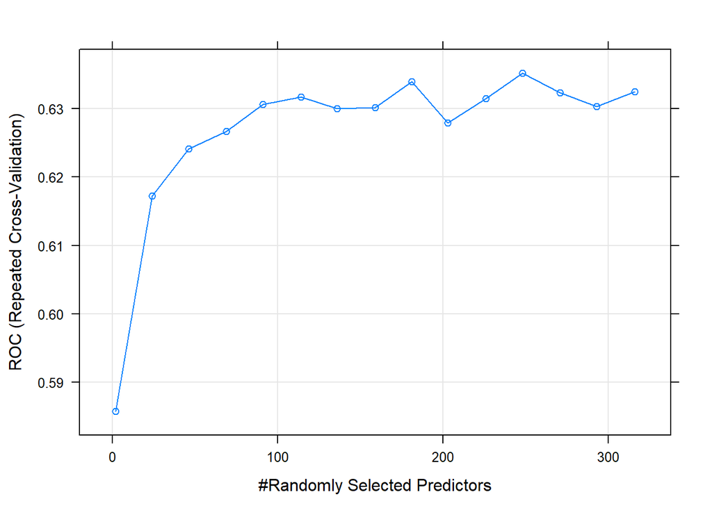

```r
rfFit <- train(
  Y ~ .,
  data = cancertraining_acp,
  method = "rf",
  tuneLength = 15, #donne le nombre de valeurs à essayer pour chaque paramètre à faire varier (ici nombre de variables à prendre en compte)
  trControl = ctrl,
  metric = "ROC"
)

#pour comparer les méthodes, on peut choisir la métrique ROC (=classer les individus dans le bon ordre), qui est une des sorties de twoClassSummary.

plot(rfFit)
```

Le modèle ayant la meilleure prédiction par validation croisée est alors sous **finalModel** dans la sortie.

```r
decision <- rfFit$finalModel
```

Pour finir, regardons les performances de l’arbre ainsi appris sur le jeu test

```r
cartPred <- predict(rfFit,cancertest_acp)

confusionMatrix(data=cartPred,cancertest_acp$Y)
```

```
## Confusion Matrix and Statistics
##
##           Reference
## Prediction  no yes
##        no  304 142
##        yes  16  13
##
##                Accuracy : 0.6674
##                  95% CI : (0.623, 0.7096)
##     No Information Rate : 0.6737
##     P-Value [Acc > NIR] : 0.6359
##
##                   Kappa : 0.0429
##
##  Mcnemar's Test P-Value : <2e-16
##
##             Sensitivity : 0.95000
##             Specificity : 0.08387
##          Pos Pred Value : 0.68161
##          Neg Pred Value : 0.44828
##              Prevalence : 0.67368
##          Detection Rate : 0.64000
##    Detection Prevalence : 0.93895
##       Balanced Accuracy : 0.51694
##
##        'Positive' Class : no
##
```

Au vu de la matrice de confusion, on voit qu’il y a toujours le même problème, on a le taux de vrais négatifs qui est très élevé mais le taux de vrais positifs est extrêmement faible. Cependant l’accuracy n’est pas trop mauvais, il est de 0.67 (67%)

2. **Par SVM**

Le début est exactement le même que pour les forêt aléatoires. On a toujours le jeu d’apprentissage et le jeu test. On réutilise donc les mêmes. Donc dans un premier temps, on est sur le jeu d’apprentissage.

```r
linearsvm_acp <-  svm(formula = Y~.,
                  data = cancertraining_acp,
                  type = 'C-classification',
                  kernel = 'linear')

gaussiansvm_acp <- svm(formula = Y~.,
                   data = cancertraining_acp,
                   type = 'C-classification',
                   kernel = 'radial')
```

Une fois les deux méthodes apprises, on va faire la prédiction sur le jeu test.

```r
linearpred_acp <- predict(linearsvm_acp, newdata = cancertest_acp)
gaussianpred_acp <- predict(gaussiansvm_acp, newdata = cancertest_acp)
```

et on sort les matrices de confusion pour les deux méthodes

```r
confusionMatrix(data=linearpred_acp,cancertest$Y)
```

```
## Confusion Matrix and Statistics
##
##           Reference
## Prediction  no yes
##        no  244  98
##        yes  76  57
##
##                Accuracy : 0.6337
##                  95% CI : (0.5886, 0.6771)
##     No Information Rate : 0.6737
##     P-Value [Acc > NIR] : 0.9709
##
##                   Kappa : 0.1352
##
##  Mcnemar's Test P-Value : 0.1114
##
##             Sensitivity : 0.7625
##             Specificity : 0.3677
##          Pos Pred Value : 0.7135
##          Neg Pred Value : 0.4286
##              Prevalence : 0.6737
##          Detection Rate : 0.5137
##    Detection Prevalence : 0.7200
##       Balanced Accuracy : 0.5651
##
##        'Positive' Class : no
##
```

```r
confusionMatrix(data=gaussianpred_acp,cancertest$Y)
```

```
## Confusion Matrix and Statistics
##
##           Reference
## Prediction  no yes
##        no  316 151
##        yes   4   4
##
##                Accuracy : 0.6737
##                  95% CI : (0.6295, 0.7157)
##     No Information Rate : 0.6737
##     P-Value [Acc > NIR] : 0.5218
##
##                   Kappa : 0.0176
##
##  Mcnemar's Test P-Value : <2e-16
##
##             Sensitivity : 0.98750
##             Specificity : 0.02581
##          Pos Pred Value : 0.67666
##          Neg Pred Value : 0.50000
##              Prevalence : 0.67368
##          Detection Rate : 0.66526
##    Detection Prevalence : 0.98316
##       Balanced Accuracy : 0.50665
##
##        'Positive' Class : no
##
```

Au vu des accuracy obtenu, la méthode SVM par noyau gaussien est la plus adaptée.

3. **par régression pénalisée**

Le début est exactement le même que pour les forêt aléatoires. On a toujours le jeu d’apprentissage et le jeu test. On réutilise donc les mêmes. Donc dans un premier temps, on est sur le jeu d’apprentissage.

```r
#jeu d'apprentissage
y.train_acp <- cancertraining_acp %>% select(Y) %>% as.matrix()
x.train_acp <- cancertraining_acp %>% select(-Y) %>% as.matrix()
```

Pénalité Ridge

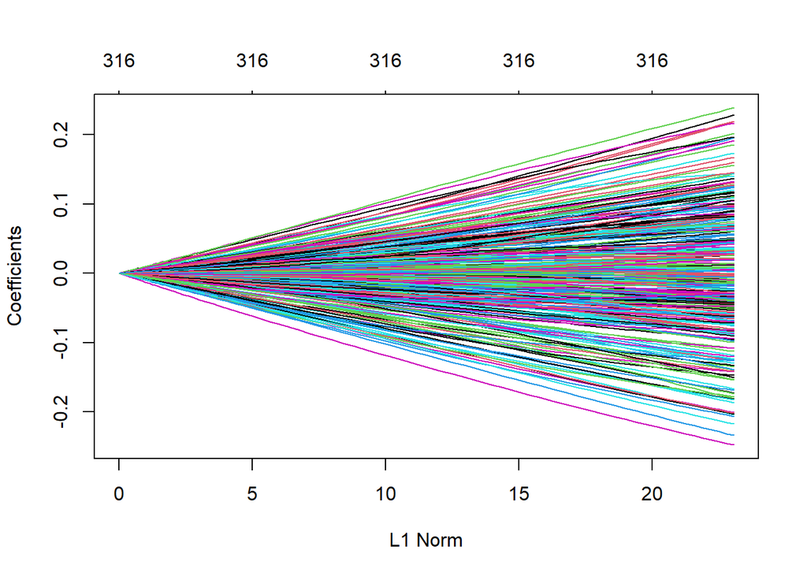

```r
model.ridge_acp <- glmnet(x.train_acp,y.train_acp,family = "binomial" ,alpha=0)
plot(model.ridge_acp)
```

Pénalité Lasso

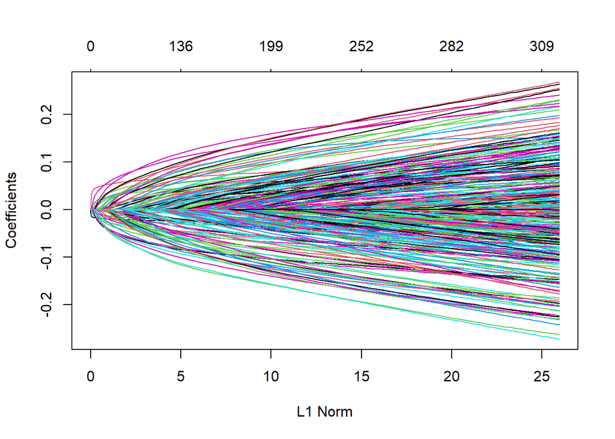

```r
model.lasso_acp <- glmnet(x.train_acp,y.train_acp,family = "binomial" , alpha=1)
plot(model.lasso_acp)
```

Pénalité Elastic net

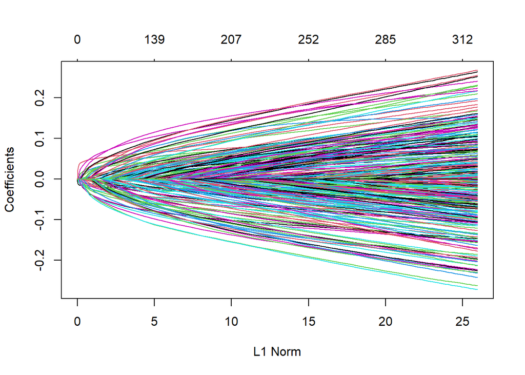

```r
model.enet_acp <- glmnet(x.train_acp,y.train_acp,family = "binomial", alpha=0.5)
plot(model.enet_acp)
```

Une fois la pénalité choisi (ici je décide de choisir elastic net, car c’est un bon compromis entre Ridge et Lasso), on procède par validation croisé pour la prédiction.

```r
cancer.cv_acp <- cv.glmnet(x.train_acp,y.train_acp,nfolds=5,family="binomial" )
cancer.cv_acp$lambda.min
```

```
## [1] 0.01735749
```

```r
model.en.cv_acp <- glmnet(x.train_acp,y.train_acp,family="binomial" ,alpha=0.5,nlambda=1,lambda=cancer.cv_acp$lambda.min)
```

```r
cancerpredict.en.cv_acp <- predict(model.en.cv_acp,x.train_acp,type="response", family="binomial" )
results_acp <- tibble(proba=cancerpredict.en.cv_acp,MAP=round(cancerpredict.en.cv_acp),truth=(y.train_acp=="yes") *1 )
results_acp
```

```
## # A tibble: 1,429 x 3
##    proba[,"s0"] MAP[,"s0"] truth[,"Y"]
##           <dbl>      <dbl>       <dbl>
##  1       0.0999          0           0
##  2       0.153           0           0
##  3       0.285           0           0
##  4       0.344           0           1
##  5       0.407           0           1
##  6       0.139           0           0
##  7       0.138           0           0
##  8       0.222           0           0
##  9       0.115           0           1
## 10       0.0500          0           0
## # ... with 1,419 more rows
```

```r
confusionMatrix(data=as_factor(results_acp$MAP),as_factor(results_acp$truth))
```

```
## Confusion Matrix and Statistics
##
##           Reference
## Prediction   0   1
##          0 912 306
##          1  50 161
##
##                Accuracy : 0.7509
##                  95% CI : (0.7276, 0.7731)
##     No Information Rate : 0.6732
##     P-Value [Acc > NIR] : 8.971e-11
##
##                   Kappa : 0.3409
##
##  Mcnemar's Test P-Value : < 2.2e-16
##
##             Sensitivity : 0.9480
##             Specificity : 0.3448
##          Pos Pred Value : 0.7488
##          Neg Pred Value : 0.7630
##              Prevalence : 0.6732
##          Detection Rate : 0.6382
##    Detection Prevalence : 0.8523
##       Balanced Accuracy : 0.6464
##
##        'Positive' Class : 0
##
```

3. **par auto-encodeur** Les encodeurs automatiques sont des réseaux de neurones où le réseau vise à prédire l’entrée en utilisant moins de nœuds cachés que les nœuds d’entrée.

Pour utiliser un auto-encodeur, il faut utiliser le package tenserflow() ou encore le package keras.

Cependant je n’ai pas réussi à réaliser cette partie..

```r
library(keras)
```

jeu d’apprentissage

```r
x.train_auto<-as.matrix(x.train)
```

le modèle

```r
#model<-keras_model_sequential()
```

Après avoir réalisé ces 9 méthodes de prédiction possibles pour votre problème. Discuter de leurs avantages et inconvénients respectifs, et de l’utilité d’une réduction de dimension dans ce cas. Mettre en oeuvre tout ou partie de de ces méthodes. Décider de laquelle vous choisiriez et évaluer ses performances.

Tout d’abord on peu discuter des avantages et des inconvénients de chacune des méthodes de prédiction:

1. forêt aléatoire
- Avantages: pas de surapprentissage, paramètre facile à déterminer.
- Inconvénients: son principale inconvénient est qu’un grand nombre d’arbres peut rendre l’algorithme trop lent et inefficace pour les prédictions en temps réel.
2. Méthode SVM
- Avantages: précision sur la prédiction, fonctionne bien sur de petits jeux de données
- Inconvénients: ne convient pas aux jeux de données trop volumineux, Difficulté d’interprétations
3. Régression pénalisée
- Avantages: en utilisant elastic-net permet de conserver les avantages de Lasso et de Ridge
- Inconvénients: il y a un nouveau paramètres à définir

La réduction d’une dimension dans notre cas est utile car initialement on a 666 variables pour 1429 observations dans le cas du jeu de données apprentissage et pour 475 données dans le cas du jeu de données test.  
On peut donc déjà dire que les trois méthodes utilisant aucune réduction de dimension ne sont pas avantageuses.  
Dans un deuxième temps, la réduction de dimension par ACP peut être une bonne méthode cependant dans mon cas j’obtiens toujours beaucoup de variables même si celles-ci on diminué de moitié.  
Et enfin la méthode de l’auto-encodeur. Je n’ai pas réussi à utiliser cette méthode

# 3. Sélection

### Proposer une ou plusieurs manières d’effectuer cette sélection à l’aide d’une approche de sélection par stabilité. Mettre en oeuvre une telle approche et proposer un ensemble d’ARN/mutations candidats à une étude approfondie.

On lance B bootstrap, on apprend sur chacun d’eux un modèle lasso (alpha = 1) avec trop de gènes et on regarde quels sont les ARN/mutations les plus fréquemment sélectionnés).  
Dans ce case j’ai utilisé la méthode avec pénalités Lasso avec aucune réduction de dimension. On utilise donc 3 fonctions utilisés précédemment dans la partie avec aucune réduction de dimension pour la méthode par régression pénalisée.

```r
B=100                              # nombre de bootstraps
ncandidats <- dim(x.train)[1]
selected <- rep(0,dim(x.train)[2])
for (b in 1:B){
  #echantillon bootstrap
  bootsample <- sample(1:ncandidats,ncandidats,replace=TRUE)
  x.boot <- x.train[bootsample,]
  y.boot <- y.train[bootsample,]
  #apprentissage
  model.lasso.boot <- glmnet(x.boot,y.boot,family="binomial",alpha=1,nlambda=1,lambda=.5*cancer.cv$lambda.min)
  selectedmutations <- model.lasso.boot$beta@i
  for (i in selectedmutations){
    selected[i] <- selected[i] +1
  }
}

#restriction du jeu d'apprentissage aux mutations étant sélectionnés au moins 1/2 du temps
selection <- which(selected>B/2)
x.train.stab <- as.tibble(x.train[,selection])
cancertrain.stab <- x.train.stab %>% add_column(Y=(y.train=="yes")*1)


# apprentissage suivant un modèle linéaire classique
model <- glm(Y~.,data=cancertrain.stab,family = binomial(link = "logit"))
predictions <- predict(model,newdata = cancertest,type="response")
confusionMatrix(data=as_factor(round(predictions)),as_factor((cancertest$Y=="yes")*1))
```

```
## Confusion Matrix and Statistics
##
##           Reference
## Prediction   0   1
##          0 273 121
##          1  47  34
##
##                Accuracy : 0.6463
##                  95% CI : (0.6015, 0.6893)
##     No Information Rate : 0.6737
##     P-Value [Acc > NIR] : 0.9061
##
##                   Kappa : 0.0827
##
##  Mcnemar's Test P-Value : 1.781e-08
##
##             Sensitivity : 0.8531
##             Specificity : 0.2194
##          Pos Pred Value : 0.6929
##          Neg Pred Value : 0.4198
##              Prevalence : 0.6737
##          Detection Rate : 0.5747
##    Detection Prevalence : 0.8295
##       Balanced Accuracy : 0.5362
##
##        'Positive' Class : 0
##
```

La fonction x.train.stab retourne un tibble avec les mutations étant sélectionnées au moins la moitié du temps. On obtient 101 variables regroupant les mutations et les expressions des gènes qui sont le plus souvent sélectionnées.